# Rogers Castro Migration Models with rcbayes

### Estimating migration age schedules using the Rogers-Castro model

#### Overview

The `mig_estimate_rc` function returns estimated Rogers-Castro parameters and $m(x)$ values, based on observed age-specific migration data and the Rogers-Castro components to be included in the model. The function has the capability of estimating a Rogers-Castro age schedule with any combination of the components `pre_working_age`, `working_age`, `retirement` and `post_retirement`. These are specified as logicals (either `TRUE` or `FALSE`) in the function.

As illustrated above, Rogers-Castro migration age schedules are highly non-linear, as so are not necessarily straight forward to estimate. Previous approaches have used, for example, Excel’s Solver function or the `optim` function in `R`.[^1] However, the estimated parameters and schedules are highly sensitive to the initial values chosen for the parameter values, and convergence is difficult to achieve for the 11 and 13 parameter models.

In `rcbayes`, we estimate Rogers-Castro schedules in a Bayesian framework using a Markov Chain Monte Carlo (MCMC) algorithm, via the Stan programming language (Carpenter et al. 2017). The use of Bayesian methods allows for priors to be set on parameters, which helps convergence in the estimation process.

##### Required Inputs for `mig_estimate_rc`

The following arguments are required for the `mig_estimate_rc` function:

- `ages`, `pre_working_age`, `working_age`, `retirement` and `post_retirement`
- Either
  - `migrants` and `pop` to provide data on the number of age-specific migrants and age-specific population OR
  - `mx` to provide data on age-specific migration rates

That is, users have an option to input their data as counts or as rates. Depending on which one is used, a different model will be run. If the user provides data as counts using `migrants` and `pop`, a Poisson model will be applied. If the user provides data as rates, a Normal model will be applied.

When running `mig_estimate_rc`, a message will appear informing the user of which model is run.

##### Optional Inputs for `mig_estimate_rc`

In the case that the Normal model is used (i.e., the user inputs age-specific migration rates using the argument `mx`), the user can use the optional argument `sigma` to input the standard deviation for the normal model. If this optional input is not used, the value of `sigma` is estimated.

Regardless of which model is used, any additional arguments for `mig_estimate_rc` will be additional inputs to `rstan::stan()`.

#### Example: Estimating migration rates for population with large retirement peak

In this example, we will fit an 11-parameter model to a set of observed age-specific rates from a population that resembles 1% of the Florida population in the United States. First, we can plot the observed rates to get a sense of what the age schedule looks like

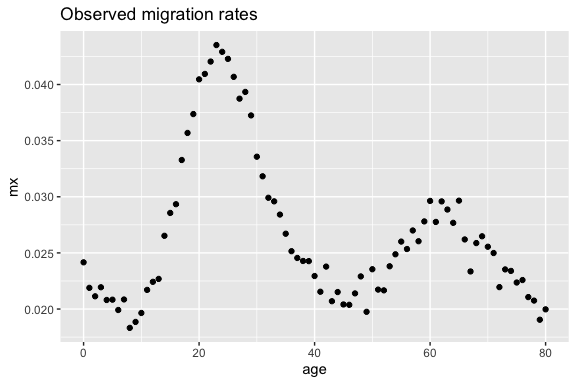

```r
fl_ages <- 0:80
fl_migrants <- c(49, 48, 48, 52, 50, 45, 42, 46, 45, 44, 47, 55, 57, 59, 67, 69, 71, 78, 93, 88, 116,
              106, 102, 104, 102, 123, 112, 102, 112, 105, 100, 83, 81, 77, 78, 77, 66, 64, 65, 64,
              68, 52, 59, 51, 54, 55, 52, 58, 64, 53, 68, 53, 57, 67, 71, 78, 75, 77, 77, 83, 88,
              80, 84, 79, 77, 83, 71, 59, 65, 67, 64, 63, 56, 50, 43, 46, 46, 38, 32, 28, 29)
fl_pop <- c(2028, 2193, 2271, 2370, 2403, 2160, 2109, 2206, 2456, 2334, 2392, 2534, 2542, 2601, 2526,
         2416, 2420, 2344, 2606, 2355, 2867, 2589, 2426, 2390, 2377, 2909, 2753, 2633, 2847, 2819,
         2979, 2608, 2708, 2602, 2745, 2883, 2624, 2607, 2677, 2637, 2964, 2414, 2481, 2464, 2510,
         2695, 2552, 2711, 2794, 2683, 2888, 2439, 2631, 2814, 2854, 2999, 2959, 2852, 2957, 2985,
         2970, 2882, 2839, 2737, 2782, 2799, 2710, 2527, 2512, 2530, 2505, 2521, 2551, 2125, 1838,
         2057, 2037, 1804, 1542, 1470, 1452)

df <- tibble(age = fl_ages, mx = fl_migrants / fl_pop)
df %>%
  ggplot(aes(age, mx)) +
  geom_point() +
  ggtitle("Observed migration rates")
```

Let’s fit a Rogers-Castro migration age schedule to these data. Below, we choose to estimate parameters associated with the pre-working age, working and retirement components (but not post retirement). We also provide the data as counts, which means that we are fitting a Poisson model.

```r
rc_res <- mig_estimate_rc(
  ages=fl_ages, migrants=fl_migrants, pop=fl_pop,
  pre_working_age = TRUE,
  working_age = TRUE,
  retirement = TRUE,
  post_retirement = FALSE,
  # (optional) arguments for Stan
  chains = 4,
  iter = 2000,
  control = list(adapt_delta = 0.8, max_treedepth = 10)
)
```

The `mig_estimate_rc` function also allows for addition arguments that are related to the Stan model. In the example above, the values listed for `chains`, `iter`, `adapt_delta` and `max_treedepth` are the default values, so need have not been specified. However, depending on the context, it may make sense to increase the value of each of these components to ensure convergence. More details about these arguments can be found in the `R` help files for `rstan::stan`, and also by referring to the [Stan documentation](https://mc-stan.org/users/documentation/).

As mentioned above, this example’s data is in the form of count data. In the case that your data is in the form of migration rates, swap out the `migrants` and `pop` arguments for `mx`.

##### Checking Model Diagnostics

When fitting models in a Bayesian framework using MCMC, as in the case of `mig_estimate_rc`, one cannot simply run the model and use the results without further inspection. It is always necessary to assess the model results to ensure that the model has converged. In Bayesian models, convergence would imply that the model has converged to a particular target distribution, which is a necessary condition before you move on and use the model’s results.

One measure to check for convergence is to look at the potential scale reduction statistic, commonly referred to as the R-hat statistic (Gelman, Rubin, and others 1992). Ideally, you want to see the R-hat values close to 1 as R-hat values far greater than 1 indicate that convergence has not been achieved. Generally, Gelman et al. recommend ensuring that R-hat values are below 1.1, although there is no universally agreed upon threshold (Gelman et al. 2013). More information about R-hat values is available in the [Stan documentation](https://mc-stan.org/docs/2_26/reference-manual/notation-for-samples-chains-and-draws.html).

In addition to convergence, another difficulty around MCMC algorithms is that the samples may be autocorrelated within a chain. One way to measure this is to look at the effective sample size ($N_{eff}$), which tells us the estimation power of your dependent MCMC samples in terms of hypothetical independent samples. A low effective sample size increases the uncertainty of estimates for posterior means, variances, etc (Geyer 2011). If your effective sample size is small, you should consider increasing the number of MCMC samples. More information about the effective sample size is available in the [Stan documentation](https://mc-stan.org/docs/2_26/reference-manual/effective-sample-size-section.html).

The `check_converge` object in the function output allows you to check the R-hat values and effective sample size.

```r
rc_res[['check_converge']]
```

```
#>                    mean      se_mean    n_eff      Rhat
#> alpha1[1]   0.870226739 1.064402e-02 2978.764 0.9994766
#> alpha2[1]   0.190530488 5.443403e-04 1786.985 1.0008539
#> alpha3[1]   0.205526356 1.493772e-03 1706.259 1.0010941
#> a1[1]       0.004726264 6.112932e-05 2180.687 1.0018765
#> a2[1]       0.058373658 1.179189e-04 1821.751 1.0003259
#> a3[1]       0.019992050 1.049587e-04 1671.263 1.0028921
#> mu2[1]     24.985308597 2.063815e-02 2198.856 1.0002768
#> mu3[1]     64.849212229 1.922614e-02 2799.851 1.0007112
#> lambda2[1]  0.140144946 3.200103e-04 1860.819 1.0020920
#> lambda3[1]  0.128113472 6.631156e-04 1639.289 1.0003709
#> c           0.020058990 3.597556e-05 1002.953 1.0015354
```

In this example, the R-hat values are all close to 1 and effective sample sizes are sufficiently large. We can move on to interpreting the model’s results.

For more details and examples on how to deal with a non-convergent model, please see the `rcbayes` vignette *Achieving Model Convergence With mig_estimate_rc*.

##### Examining Model Results

After ensuring that the model has converged properly, you can interpret the results of the model. There are two objects in the function’s output for this purpose.

The `fit_df` object shows the data and estimated median $m(x)$ values at each age $x$, along with the lower and upper bound of the 95% credible interval of the fits, and the squared difference between data and the median estimate.

```r
rc_res[['pars_df']]
```

```
#> # A tibble: 11 × 4
#>    variable   median     lower   upper
#>    <chr>       <dbl>     <dbl>   <dbl>
#>  1 a1        0.00439  0.000416  0.0111
#>  2 a2        0.0585   0.0485    0.0680
#>  3 a3        0.0200   0.0116    0.0288
#>  4 alpha1    0.752    0.0676    2.26
#>  5 alpha2    0.190    0.148     0.238
#>  6 alpha3    0.196    0.113     0.353
#>  7 c         0.0202   0.0172    0.0219
#>  8 lambda2   0.139    0.116     0.169
#>  9 lambda3   0.125    0.0861    0.191
#> 10 mu2      25.0     23.1      26.9
#> 11 mu3      64.8     62.9      66.8
```

```r
rc_res[['fit_df']]
```

```
#> # A tibble: 81 × 6
#>     ages   data median  lower  upper      diff_sq
#>    <int>  <dbl>  <dbl>  <dbl>  <dbl>        <dbl>
#>  1     0 0.0242 0.0245 0.0206 0.0311 0.0000000885
#>  2     1 0.0219 0.0221 0.0200 0.0251 0.0000000584
#>  3     2 0.0211 0.0212 0.0194 0.0235 0.0000000103
#>  4     3 0.0219 0.0208 0.0191 0.0227 0.00000122
#>  5     4 0.0208 0.0206 0.0189 0.0224 0.0000000306
#>  6     5 0.0208 0.0205 0.0188 0.0222 0.000000109
#>  7     6 0.0199 0.0204 0.0187 0.0220 0.000000257
#>  8     7 0.0209 0.0204 0.0186 0.0220 0.000000219
#>  9     8 0.0183 0.0204 0.0187 0.0220 0.00000430
#> 10     9 0.0189 0.0205 0.0189 0.0220 0.00000266
#> # … with 71 more rows
```

We can plot the observed data and estimated fit using the `fit_df` object:

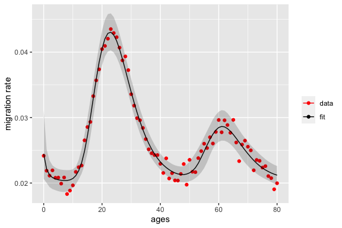

```r
rc_res[["fit_df"]] %>%
  ggplot(aes(ages, data)) +
  geom_point(aes(color = "data")) +
  geom_line(aes(x = ages, y = median, color = "fit")) +
  geom_ribbon(aes(ymin = lower, ymax = upper), alpha = 0.2) +
  scale_color_manual(name = "", values = c(data = "red", fit = "black")) +
  ylab("migration rate")
```

##### Comments about warnings

When using `mig_estimate_rc` it is not unusual to see warnings from Stan, particularly when the retirement and post-retirement families are included in the model. These may include warnings about divergent transitions, low effective sample size and maximum treedepth. If you see these warnings, you should take special care in determining whether your model converged properly.

For more in-depth examples of dealing with warnings and convergence issues, please see the `rcbayes` vignette *Achieving Model Convergence With mig_estimate_rc*.

## References

Carpenter, Bob, Andrew Gelman, Matthew D Hoffman, Daniel Lee, Ben Goodrich, Michael Betancourt, Marcus Brubaker, Jiqiang Guo, Peter Li, and Allen Riddell. 2017. “Stan: A Probabilistic Programming Language.” *Journal of Statistical Software* 76 (1).

Gelman, Andrew, John B Carlin, Hal S Stern, David B Dunson, Aki Vehtari, and Donald B Rubin. 2013. *Bayesian Data Analysis*. CRC press.

Gelman, Andrew, Donald B Rubin, and others. 1992. “Inference from Iterative Simulation Using Multiple Sequences.” *Statistical Science* 7 (4): 457–72.

Geyer, Charles. 2011. “Introduction to Markov Chain Monte Carlo.” *Handbook of Markov Chain Monte Carlo* 20116022: 45.

Preston, Samuel, Patrick Heuveline, and Michel Guillot. 2000. *Demography: Measuring and Modeling Population Processes*. Wiley-Blackwell.

Rogers, Andrei, and Luis J Castro. 1981. “Model Migration Schedules.” *IIASA Working Papers*.

Rogers, Andrei, Jani Little, and James Raymer. 2010. *The Indirect Estimation of Migration: Methods for Dealing with Irregular, Inadequate, and Missing Data*. Vol. 26. Springer Science & Business Media.

[^1]: http://demographicestimation.iussp.org/content/multi-exponential-model-migration-schedule